# Gradient Boosting Machine (GBM) Baseline Tutorial

#### This tutorial will use python to fit the baseline GBM model shown on the leaderboard and generate the corresponding submission.

A fundamental understanding of GBM models is assumed, please seek resources to improve understanding and use this tutorial as a computational example.

Some mathematical reading can be found [here](http://scikit-learn.org/stable/modules/ensemble.html#mathematical-formulation)

#### Read Data

```python
import pandas as pd

train = pd.read_csv('trainingData.csv')
test = pd.read_csv('testingData.csv')
```

#### Error Metric

R-Bloggers has a nice article on explaining the Log Loss function which can be read [here](https://www.r-bloggers.com/making-sense-of-logarithmic-loss/)

```python
import numpy as np

def log_loss_binary(actual, predicted, eps = 1e-15):
    predicted = np.minimum(np.maximum(predicted, eps), 1 - eps)

    return -(sum(actual * np.log(predicted) + (1. - actual) * np.log(1. - predicted))) / len(actual)
```

#### Fit GBM

Fit a model with the equation `response = foodType + burglary + ward + sanitation`

We will use the scikit-learn module to fit a GBM model. To work with scikit-learn, we will need at data to look a specific way. We should input clean numeric data.

#### Check Data Types:

```python
print 'Food type has a data type of:  ' + str(train['foodType'].dtype)
print 'Burglary has a data type of:   ' + str(train['burglary'].dtype)
print 'Ward has a data type of:       ' + str(train['ward'].dtype)
print 'Sanitation has a data type of: ' + str(train['sanitation'].dtype)
```

```
Food type has a data type of:  object
Burglary has a data type of:   float64
Ward has a data type of:       float64
Sanitation has a data type of: float64
```

The variable `foodType` could prove to be problematic. We have a few options for how we could handle this. Firstly we could change each of the values found in `foodType` to a numeric value:

`['mart', 'unknown', 'dinner', ..., 'dessert'] -> [0, 1, 2, ..., 11]`

For some algorithms, this is not good practise as we are assuming that the distance between `'mart'` and `'unknown'` is the same as the distance from `'unknown'` to `'dinner'` however for tree based algorithms this is not the case.

Another option could be to create numeric boolean flags indicating if a record contains a certain level. These are called dummy variables. The code below shows how the first 5 records would be transformed.

```python
dummy_data = pd.get_dummies(train['foodType'].head())

print pd.concat([train['foodType'].head(), dummy_data], axis = 1)
```

```
  foodType  dinner  mart  unknown
0     mart     0.0   1.0      0.0
1  unknown     0.0   0.0      1.0
2   dinner     1.0   0.0      0.0
3   dinner     1.0   0.0      0.0
4  unknown     0.0   0.0      1.0
```

```python
dummy_train = pd.get_dummies(train['foodType'])
```

#### Check Clean Data:

```python
print 'Food type has:  ' + str(sum(train['foodType'].isnull()))   + '  missing values'
print 'Burglary has:   ' + str(sum(train['burglary'].isnull()))   + '  missing values'
print 'Ward has:       ' + str(sum(train['ward'].isnull()))       + ' missing values'
print 'Sanitation has: ' + str(sum(train['sanitation'].isnull())) + '  missing values'
```

```
Food type has:  0  missing values
Burglary has:   0  missing values
Ward has:       32 missing values
Sanitation has: 0  missing values
```

Here the variable `ward` looks problematic. We can impute the missing values or create a missing indicator and then set missings to an imputed or arbitrary value.

```python
train['ward_missing'] = 1. * (train['ward'].isnull())

train.loc[train['ward_missing'] == 1, 'ward'] = 0.
```

#### Fit GBM

```python
from sklearn import ensemble
from sklearn import grid_search

baseline_model = ensemble.GradientBoostingRegressor(
                                                    loss = 'ls',
                                                    learning_rate = 0.1,
                                                    subsample = 0.7,
                                                    min_samples_leaf = 5,
                                                    max_depth = 5
                                                   )

numeric_predictors = ['burglary', 'ward', 'sanitation', 'ward_missing']

X = pd.concat([dummy_train, train[numeric_predictors]], axis = 1)
y = train['response']

trees_to_search_over = {'n_estimators': range(100, 401, 100)}
grid_model = grid_search.GridSearchCV(estimator = baseline_model,
                                      param_grid = trees_to_search_over,
                                      n_jobs = 4,
                                      iid = False,
                                      verbose = 2,
                                      cv = 5)

grid_model.fit(X, y)

# print out the best cv fold combination:"
print 'Best parameter combinations:' + str(grid_model.best_params_)

# fit the estimator with the best cv fold combination:
grid_model.estimator.fit(X, y)
```

[output not shown]

```
[Parallel(n_jobs=4)]: Done  20 out of  20 | elapsed:   11.7s finished
```

```
Best parameter combinations:{'n_estimators': 100}
```

```
GradientBoostingRegressor(alpha=0.9, init=None, learning_rate=0.1, loss='ls',
             max_depth=5, max_features=None, max_leaf_nodes=None,
             min_samples_leaf=5, min_samples_split=2,
             min_weight_fraction_leaf=0.0, n_estimators=100,
             presort='auto', random_state=None, subsample=0.7, verbose=0,
             warm_start=False)
```

```python
feature_importance = pd.DataFrame({
                                   'feature': X.columns,
                                   'importance': grid_model.estimator.feature_importances_
                                  })

print feature_importance.sort_values(by = 'importance', ascending = False)
```

```
         feature  importance
12      burglary    0.360284
14    sanitation    0.318634
13          ward    0.218928
11       unknown    0.014533
8           mart    0.012975
5         dinner    0.010491
6        grocery    0.009750
9       sandwich    0.009267
1            bar    0.009101
0          asian    0.008697
7        italian    0.006209
3          cater    0.006081
2      breakfast    0.005595
4        dessert    0.004817
10       spanish    0.004639
15  ward_missing    0.000000
```

```python
baseline_predictions = grid_model.estimator.predict(X)

log_loss_binary(train.response, baseline_predictions)
```

```
0.54928201441969682
```

#### Output Predictions for Submission

First we need to recreate the transforms we preformed.

```python
dummy_test = pd.get_dummies(test['foodType'])

test['ward_missing'] = 1. * (test['ward'].isnull())
test.loc[test['ward_missing'] == True, 'ward'] = 0.

testX = pd.concat([dummy_test, test[numeric_predictors]], axis = 1)

# score the model on our test data:
test_prediction = grid_model.estimator.predict(testX)

# create a DataFrame for submission:
outputDF = pd.DataFrame({
                         'inspectionId': test.inspectionId,
                         'response': test_prediction
                         })

outputDF.to_csv('baseline_predictions.csv', index = False)
```

# Xtreme Boosting

If you're feeling adventurous then check out the [XGBoost](http://xgboost.readthedocs.io/en/latest/) implementation of Gradient Boosting. It doesn't come as standard in the Anaconda distribution of Python and so will likely cause some heahaches trying to install.

#### Wrestle with Data

XGBoost uses an internal data structure which is optimized for both memory efficiency and training speed.

```python
import xgboost as xgb

dtrain = xgb.DMatrix(data = X, label = y)
```

Set up the algorithm parameters. The docstrings are awful, so definitions can be found here: https://github.com/dmlc/xgboost/blob/master/doc/parameter.md

```python
params = {
          'max_depth': 5,
          'eta': 0.1,
          'silent': 0,
          'objective': 'binary:logistic',
          'eval_metric': 'logloss',
          'nthread': 4,
          'min_child_weight': 5
          }

num_round = 100
```

```python
model_cv = xgb.cv(params = params,
                  dtrain = dtrain,
                  num_boost_round = num_round,
                  nfold = 5,
                  verbose_eval = True)

# find best tree from cross validation. note index will be returned which is zero indexed (index + 1)
optimal_number_of_trees = model_cv['test-logloss-mean'].argmin() + 1

print optimal_number_of_trees
```

```
39
```

```python
model = xgb.train(params = params,
                  dtrain = dtrain,
                  num_boost_round = optimal_number_of_trees)
```

```python
xgb_predictions = model.predict(dtrain)

log_loss_binary(train.response, xgb_predictions)
```

```
0.59688134080009791
```

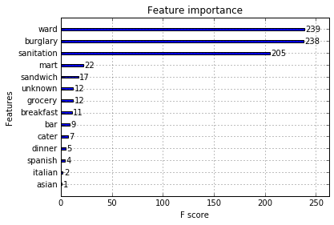

```python
%matplotlib inline

xgb.plot_importance(model)
```

```python
dTest = xgb.DMatrix(testX)
test_xgb_predictions = model.predict(dTest)

# I shouldn't have access to the testing response, but I do :O !!!
validate_response = pd.read_csv('testingDataResponse.csv')

test['response'] = validate_response['response']

log_loss_binary(test.response, test_xgb_predictions)
```

```
0.615612292441585
```